# Social Network Analysis: Lab Exercise 1

### Ζ) Υπολογισμός κεντρικότητας κόμβων

**ΟΡΙΣΜΟΙ**

**Degree centrality** of a node refers to the number of edges attached to the node. In order to know the standardized score, you need to divide each score by $n-1$ (n: the number of nodes).  
**Closeness centrality** (or closeness) of a node is a measure of centrality in a network, calculated as the reciprocal of the sum of the length of the shortest paths between the node and all other nodes in the graph. Thus, the more central a node is, the closer it is to all other nodes.  
\begin{align*} C(x) = \frac{1}{\sum_y d(y,x)} \end{align*}  
**Betweenness centrality** is a way of detecting the amount of influence a node has over the flow of information in a graph. It is often used to find nodes that serve as a bridge from one part of a graph to another. Betweenness centrality is a measure of centrality in a graph based on shortest paths. For every pair of vertices in a connected graph, there exists at least one shortest path between the vertices such that either the number of edges that the path passes through (for unweighted graphs) or the sum of the weights of the edges (for weighted graphs) is minimized. The betweenness centrality for each vertex is the number of these shortest paths that pass through the vertex.

###### - σ(s,t)

Number of shortest paths between nodes s and t

###### - σ(s,t|v)

Number of shortest paths between nodes s and t that pass through v.

\begin{align*} C_B(v) = \frac{\sum_s \sum_t σ(s,t|v)}{\sum_s \sum_t σ(s,t)}, \end{align*}

**Eigenvector centrality** (also called eigencentrality) is a measure of the influence of a node in a network. It assigns relative scores to all nodes in the network based on the concept that connections to high-scoring nodes contribute more to the score of the node in question than equal connections to low-scoring nodes.

##### 1) Αναλυτικός υπολογισμός της κεντρικότητας

Για καθένα από τα παρακάτω δίκτυα υπολογίστε αναλυτικά (να φαίνονται οι πράξεις) τις εξής μετρικές κεντρικότητας:

- degree centrality
- closeness centrality
- betweenness centrality

και συγκρίνετε/σχολιάστε τα αποτελέσματα

```
Topology A
Degree Centrality: {0: 1.0, 1: 0.3333333333333333, 2: 0.3333333333333333, 3: 0.3333333333333333}
Closeness Centrality: {0: 1.0, 1: 0.6, 2: 0.6, 3: 0.6}
Betweenness Centrality: {0: 1.0, 1: 0.0, 2: 0.0, 3: 0.0}

Topology B
Degree Centrality: {0: 1.0, 1: 1.0, 2: 1.0, 3: 1.0}
Closeness Centrality: {0: 1.0, 1: 1.0, 2: 1.0, 3: 1.0}
Betweenness Centrality: {0: 0.0, 1: 0.0, 2: 0.0, 3: 0.0}
```

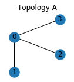

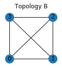

```python
plt.figure(1,figsize=(2,2))
plt.title("Topology A")
G = nx.Graph()
pos = {0: (1, 1), 1: (1, 0), 2: (1.5, 0.5), 3: (1.5, 1.5)}
G.add_nodes_from(pos.keys())
G.add_edges_from([(0,1),(0,2),(0,3)])
labels = {}
labels[0] = r'$0$'
labels[1] = r'$1$'
labels[2] = r'$2$'
labels[3] = r'$3$'
nx.draw_networkx_labels(G, pos, labels)
nx.draw(G,pos)
# Degrees
dcA = nx.degree_centrality(G)
ccA = nx.closeness_centrality(G)
bcA = nx.betweenness_centrality(G)
print("Topology A")
print("Degree Centrality: " + str(dcA))
print("Closeness Centrality: " + str(ccA))
print("Betweenness Centrality: " + str(bcA) + "\n")

plt.figure(2,figsize=(2,2))
plt.title("Topology B")
pos = {0: (0, 0), 1: (1, 0), 2: (1, 1), 3: (0, 1)}
G.add_nodes_from(pos.keys())
G.add_edges_from([(0,1),(0,2),(0,3),(1,2),(1,3),(2,3)])
labels = {}
labels[0] = r'$0$'
labels[1] = r'$1$'
labels[2] = r'$2$'
labels[3] = r'$3$'
nx.draw_networkx_labels(G, pos, labels)
nx.draw(G,pos)
# Degrees
dcB = nx.degree_centrality(G)
ccB = nx.closeness_centrality(G)
bcB = nx.betweenness_centrality(G)
print("Topology B")
print("Degree Centrality: " + str(dcB))
print("Closeness Centrality: " + str(ccB))
print("Betweenness Centrality: " + str(bcB))
```

#### Αναλυτικός υπολογισμός κεντρικοτήτων

### Τοπολογία Α

$dc_0 = 3/3 = 1$, $dc_1=dc_2=dc_3=1/3$

$closeness_0 = 3/(1+1+1)=1, closeness_1=3/(1+2+2)=0.6, closeness_2=3/(1+2+2)=0.6$,  
$closeness_3=3/(1+2+2)=0.6$

### Τοπολογία B

$dc_0 = dc_1=dc_2=dc_3=3/3=1$

$closeness_0 = closeness_1 = closeness_2 = closeness_3 = 3/(1+1+1)=1$

$betweenness_0 = betweenness_1=betweenness_2=betweenness_3=0$, αφού το γράφημα είναι μία κλίκα 4 nodes και άρα όλα τα shortest paths αποτελούνται από την ακμή μεταξύ της αρχής και του τέλους τους. Έτσι, δεν επηρεάζονται από τον υπό εξέταση κάθε φορά node.

Προφανώς, τα παραπάνω αποτελέσματα είναι τα ίδια με τα αποτελέσματα με την χρήση της βιβλιοθήκης networkx που δείξαμε παραπάνω.

##### 2) Υπολογισμός κεντρικότητας σε μεγαλύτερες συνθετικές τοπολογίες

Για κάθε μια από τις τοπολογίες REG, RG(ER), RGG, SF(BA) και SW(WS) του πίνακα, να υπολογιστεί η τοπική κεντρικότητα του κάθε κόμβου, να απεικονιστεί η συγκεντρωτική κατανομή κεντρικότητας για όλους τους κόμβους και να σχολιαστούν τα αποτελέσματα για όλες τις παρακάτω μετρικές κεντρικότητας:

- degree centrality
- closeness centrality
- betweenness centrality
- eigenvector centrality

```python
REG_degree_centrality = nx.degree_centrality(REG)
REG_closeness_centrality = nx.closeness_centrality(REG)
REG_betweenness_centrality = nx.betweenness_centrality(REG)
REG_eigenvector_centrality = nx.eigenvector_centrality(REG)

RGER_degree_centrality = nx.degree_centrality(RGER)
RGER_closeness_centrality = nx.closeness_centrality(RGER)
RGER_betweenness_centrality = nx.betweenness_centrality(RGER)
RGER_eigenvector_centrality = nx.eigenvector_centrality(RGER)

RGG_degree_centrality = nx.degree_centrality(RGG)
RGG_closeness_centrality = nx.closeness_centrality(RGG)
RGG_betweenness_centrality = nx.betweenness_centrality(RGG)
RGG_eigenvector_centrality = nx.eigenvector_centrality(RGG)

SF_degree_centrality = nx.degree_centrality(SF)
SF_closeness_centrality = nx.closeness_centrality(SF)
SF_betweenness_centrality = nx.betweenness_centrality(SF)
SF_eigenvector_centrality = nx.eigenvector_centrality(SF)

SW_degree_centrality = nx.degree_centrality(SW)
SW_closeness_centrality = nx.closeness_centrality(SW)
SW_betweenness_centrality = nx.betweenness_centrality(SW)
SW_eigenvector_centrality = nx.eigenvector_centrality(SW)

degree_centrality = [REG_degree_centrality, RGER_degree_centrality, RGG_degree_centrality, SF_degree_centrality,
                    SW_degree_centrality]
closeness_centrality = [REG_closeness_centrality, RGER_closeness_centrality, RGG_closeness_centrality,
                    SF_closeness_centrality, SW_closeness_centrality]
betweenness_centrality = [REG_betweenness_centrality, RGER_betweenness_centrality, RGG_betweenness_centrality,
                    SF_betweenness_centrality, SW_betweenness_centrality]
eigenvector_centrality = [REG_eigenvector_centrality, RGER_eigenvector_centrality, RGG_eigenvector_centrality,
                    SF_eigenvector_centrality, SW_eigenvector_centrality]

#συγκεντρωτική κατανομή των centralities στο ιδιο figure με subplots
def subplot_centrality(centrality, n, title):
    y = np.array(range(n))/float(n)
    fig, axs = plt.subplots(5)
    fig.suptitle(title)
    plt.subplots_adjust(wspace=2, hspace=2, left=0.125, right=0.9, bottom=1.1, top=2.9)
    axs[0].title.set_text("REG")
    axs[0].plot(np.sort(list(centrality[0].values())), y)
    axs[1].title.set_text("RGER")
    axs[1].plot(np.sort(list(centrality[1].values())), y)
    axs[2].title.set_text("RGG")
    axs[2].plot(np.sort(list(centrality[2].values())), y)
    axs[3].title.set_text("SF")
    axs[3].plot(np.sort(list(centrality[3].values())), y)
    axs[4].title.set_text("SW")
    axs[4].plot(np.sort(list(centrality[4].values())), y)
```

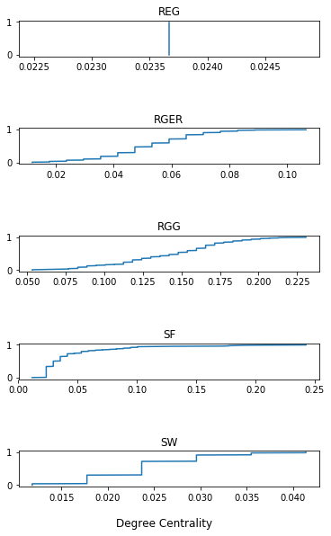

```python
subplot_centrality(degree_centrality, n, "Degree Centrality")
```

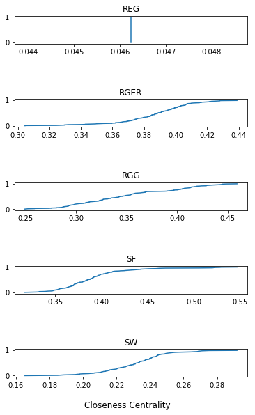

```python
subplot_centrality(closeness_centrality, n, "Closeness Centrality")
```

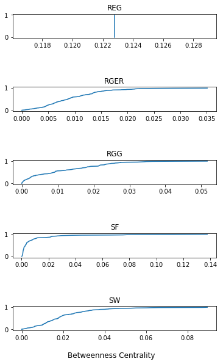

```python
subplot_centrality(betweenness_centrality, n, "Betweenness Centrality")
```

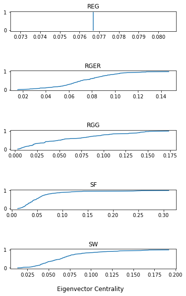

```python
subplot_centrality(eigenvector_centrality, n, "Eigenvector Centrality")
```

Για το REG model, παρατηρούμε constant centralities, αφού κάθε κόμβος έχει πάντα σταθερό αριθμό γειτόνων (4) και το μέσο ελάχιστο μονοπάτι του γράφου είναι και αυτό σταθερό, με αποτέλεσμα όλοι οι κόμβοι να έχουν την ίδια κεντρικότητα. Το μόνο που αλλάζει είναι η τίμη για κάθε είδος κεντρικότητας που μελετάμε, αφού η κάθεμια αποτελεί και διαφορετική μέθοδο μετρικής.

Για το RGER model και το RGG model, παρατηρούμε παρόμοια ποιοτικά αποτελέσματα ως προς τις κατανομές των centralities τους. Από την κατανομή της degree centrality, καταλαβαίνουμε πως προσομοιάζει αρκετά στην Uniform distribution, αφού παρατηρούμε και για τα δύο μοντέλα παρόμοιες αυξήσεις στις μετρήσεις της κεντρικότητας, στην συγκεντρωτική κατανομή, καθώς αυξάνεται ο αριθμός των κόμβων. Στις υπόλοιπες κεντρικότητες, παρατηρούμε παρόμοια συμπεριφορά και στα δυο μοντέλα, με την διαφορά ότι στο RGG model έχουμε μεγαλύτερη αύξηση κεντρικότητας από ότι στο RGER στους πρώτους κόμβους που μελετάμε. Στην συνέχεια, βλέπουμε ποιοτικά παρόμοια συμπεριφορά στην κατανομή των κεντρικοτήτων.

Για το SF model και το SW model, παρατηρούμε ότι οι κατανομές των κεντρικοτήτων τους ποικίλουν. Πιο αναλυτικά, βλέπουμε ότι για το Degree centrality, το πρώτο παρομοιάζει με Poisson distribution, ενώ το δεύτερο με Uniform distribution, για το closeness centrality και τα δύο παρομοιάζουν με παρόμοιες κατανομές, με το πρώτο να έχει την απότομη αύξηση πιο νωρίς από το δεύτερο. Επιπλέον, για την betweenness centrality παρατηρούμε ότι το SF παρομοιάζει με την power-law distribution, βλέποντας λίγους κόμβους με μεγάλη κεντρικότητα και πολλούς με μικρή, κάτι το οποίο δεν φαίνεται για το SW, το οποίο εμφανίζει μεγαλύτερη ομοιμορφία ως προς αυτή την κεντρικότητα. Τέλος, για την eigenvector centrality, τα δυο μοντέλα εμφανίζουν ομοιότητες, με το SF να εμφανίζεται πιο κοντά στην power-law distribution, ενώ το SW πιο κοντά στην heavy-tail distribution.

Στη συνέχεια να υπολογιστεί και να συγκριθεί η μέση κεντρικότητα κάθε τοπολογίας για όλες τις μετρικές.

```python
# Στη συνέχεια να υπολογιστεί και να συγκριθεί η μέση κεντρικότητα κάθε τοπολογίας για όλες τις μετρικές.
print("--- Degree centrality ---")
print("Mean degree centrality REG: %f" %np.mean([x[1] for x in REG_degree_centrality.items()]))
print("Mean degree centrality RGER: %f" %np.mean([x[1] for x in RGER_degree_centrality.items()]))
print("Mean degree centrality RGG: %f" %np.mean([x[1] for x in RGG_degree_centrality.items()]))
print("Mean degree centrality SF: %f" %np.mean([x[1] for x in SF_degree_centrality.items()]))
print("Mean degree centrality SW: %f" %np.mean([x[1] for x in SW_degree_centrality.items()]))
print()

print("--- Closeness centrality ---")
print("Mean closeness centrality REG: %f" %np.mean([x[1] for x in REG_closeness_centrality.items()]))
print("Mean closeness centrality RGER: %f" %np.mean([x[1] for x in RGER_closeness_centrality.items()]))
print("Mean closeness centrality RGG: %f" %np.mean([x[1] for x in RGG_closeness_centrality.items()]))
print("Mean closeness centrality SF: %f" %np.mean([x[1] for x in SF_closeness_centrality.items()]))
print("Mean closeness centrality SW: %f" %np.mean([x[1] for x in SW_closeness_centrality.items()]))
print()

print("--- Betweenness centrality ---")
print("Mean betweenness centrality REG: %f" %np.mean([x[1] for x in REG_betweenness_centrality.items()]))
print("Mean betweenness centrality RGER: %f" %np.mean([x[1] for x in RGER_betweenness_centrality.items()]))
print("Mean betweenness centrality RGG: %f" %np.mean([x[1] for x in RGG_betweenness_centrality.items()]))
print("Mean betweenness centrality SF: %f" %np.mean([x[1] for x in SF_betweenness_centrality.items()]))
print("Mean betweenness centrality SW: %f" %np.mean([x[1] for x in SW_betweenness_centrality.items()]))
print()

print("--- Eigenvector centrality ---")
print("Mean eigenvector centrality REG: %f" %np.mean([x[1] for x in REG_eigenvector_centrality.items()]))
print("Mean eigenvector centrality RGER: %f" %np.mean([x[1] for x in RGER_eigenvector_centrality.items()]))
print("Mean eigenvector centrality RGG: %f" %np.mean([x[1] for x in RGG_eigenvector_centrality.items()]))
print("Mean eigenvector centrality SF: %f" %np.mean([x[1] for x in SF_eigenvector_centrality.items()]))
print("Mean eigenvector centrality SW: %f" %np.mean([x[1] for x in SW_eigenvector_centrality.items()]))
```

```
--- Degree centrality ---
Mean degree centrality REG: 0.023669
Mean degree centrality RGER: 0.052210
Mean degree centrality RGG: 0.142221
Mean degree centrality SF: 0.046223
Mean degree centrality SW: 0.023669

--- Closeness centrality ---
Mean closeness centrality REG: 0.046238
Mean closeness centrality RGER: 0.386516
Mean closeness centrality RGG: 0.350263
Mean closeness centrality SF: 0.391277
Mean closeness centrality SW: 0.230629

--- Betweenness centrality ---
Mean betweenness centrality REG: 0.122781
Mean betweenness centrality RGER: 0.009508
Mean betweenness centrality RGG: 0.011402
Mean betweenness centrality SF: 0.009402
Mean betweenness centrality SW: 0.020057

--- Eigenvector centrality ---
Mean eigenvector centrality REG: 0.076696
Mean eigenvector centrality RGER: 0.072547
Mean eigenvector centrality RGG: 0.061423
Mean eigenvector centrality SF: 0.059480
Mean eigenvector centrality SW: 0.068695
```

### Η) Μελέτη συνεκτικότητας και συμπεριφορά κατωφλίων

Για κάθε τύπο σύνθετου δικτύου, ορίζεται το ποσοστό συνεκτικότητας για έναν αριθμό παραγόμενων τοπολογιών, ως κλάσμα των συνδεδεμένων τοπολογιών σε σχέση με τον αριθμό όλων των παραγόμενων τοπολογιών.

Με βάση τις τιμές παραμέτρων του Πίνακα 2, μελετήστε τη συνεκτικότητα κάθε τύπου σύνθετου δικτύου του Πίνακα 1.

Πίνακας 2

| Τοπολογία | Εύρος Παραμέτρων |  |
| --- | --- | --- |
| REG | $n = \{100, 200\}$ | $d \in [2,10]$ με βήμα $2$ |
| RGER |  | $M \in [100,800]$ με βήμα $100$ |
| RG |  | $p \in [0.1,0.9]$ με βήμα $0.1$ |
| RGG |  | $R \in [0.025,0.25]$ με βήμα $0.025$ και $L=1$ |
| SF |  | $d \in [2,10]$ με βήμα $2$ |
| SW |  | $d \in [2,10]$ με βήμα $2$ και $g_p \in [0.1,0.7]$ με βήμα $0.1$ |

Για κάθε έναν τύπο δικτύου, να παράξετε 100 διαφορετικές τοπολογίες και να παρουσιάσετε το διάγραμμα ποσοστού συνεκτικότητας σε σχέση με τις καθορισμένες παραμέτρους κάθε δικτύου.

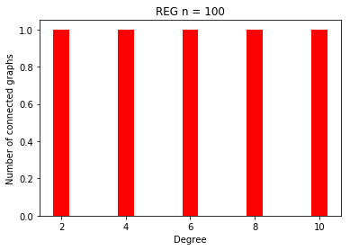

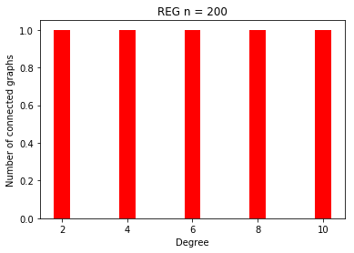

```python
#για τον έλεγχο της συνεκτικότητας, χρησιμοποίηστε την is_connected του networkx
#για τη γραφική αναπαράσταση των αποτελεσμάτων, μπορείτε να χρησιμοποίησετε την bar του matplotlib
#έλεγχος συνεκτικότητας για REG

# Επιστρεφω το ποσοστο των συνδεδεμενων γραφηματων
def REG_connect_per(d, n, fn):
    connected = 0
    for i in range(100): # 100 different topologies
        tmp_REG = fn(n,d)
        connected = connected + nx.is_connected(tmp_REG)
    return connected / 100


#plot example:
def plot_connect_REG(n, idx, fn):
    plt.figure(idx)
    y = [REG_connect_per(d, n, fn) for d in range(2,12,2)]
    plt. bar(list(range(2,12,2)),y, width=0.5, color='r')
    plt.title("REG n = %d" %n)
    plt.ylabel("Number of connected graphs")
    plt.xlabel("Degree")
    plt.show()

reg_fn = lambda n,d:nx.watts_strogatz_graph(n, d, 0)
plot_connect_REG(100, 1, reg_fn)
plot_connect_REG(200, 2, reg_fn)
```

Σχολιάστε τα αποτελέσματα συνεκτικότητας για το REG:

Λαμβάνουμε ποσοστό 100%, αφού από τον ορισμό της τοπολογίας και των ιδιοτήτων του δικτύου που έχουμε μελετήσει παραπάνω, κάθε κόμβος πρέπει να έχει σταθερό αριθμό ακμών, άρα γειτόνων. Έτσι, κάθε νέος κόμβος θα συνδέεται με σταθερό αριθμό υπάρχοντων κόμβων και άρα κάθε κόμβος θα διαθέτει μονοπάτι για οποιοδήποτε άλλο κόμβο του γραφήματος, με αποτελέσμα πάντοτε να πετυχαίνουμε συνεκτικότητα στον γράφο.

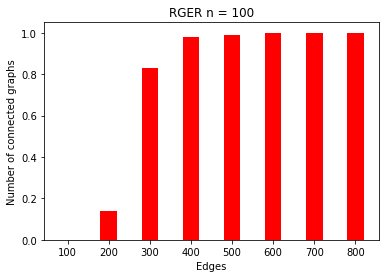

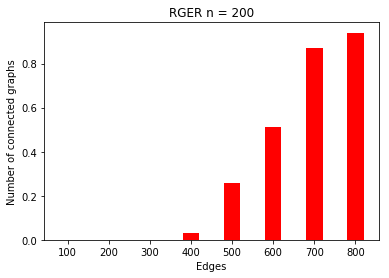

```python
#για τον έλεγχο της συνεκτικότητας, χρησιμοποίηστε την is_connected του networkx
#για τη γραφική αναπαράσταση των αποτελεσμάτων, μπορείτε να χρησιμοποίησετε την bar του matplotlib
#έλεγχος συνεκτικότητας για RGER

# Επιστρεφω το ποσοστο των συνδεδεμενων γραφηματων
def RGER_connect_per(M, n, fn):
    connected = 0
    for i in range(100): # 100 different topologies
        tmp_RGER = fn(n, M)
        connected = connected + nx.is_connected(tmp_RGER)
    return connected / 100


#plot example:
def plot_connect_RGER(n, idx, fn):
    plt.figure(idx)
    y = [RGER_connect_per(M, n, fn) for M in range(100,900,100)]
    plt.bar(list(range(100,900,100)), y, width=40, color='r')
    plt.title("RGER n = %d" %n)
    plt.ylabel("Number of connected graphs")
    plt.xlabel("Edges")
    plt.show()

rger_fn = lambda n,M:nx.gnm_random_graph(n, M)
plot_connect_RGER(100, 1, rger_fn)
plot_connect_RGER(200, 2, rger_fn)
```

Σχολιάστε τα αποτελέσματα συνεκτικότητας για το RGER:

Παρατηρούμε ότι το ποσοστό συνεκτικότητας εξαρτάται άμεσα από το πλήθος των κόμβων του γράφου. Πιο αναλυτικά, βλέπουμε ότι για μικρό αριθμό κόμβων φτάνουμε σε 100% συνεκτικότητα με λιγότερες ακμές από αυτές που θα χρειαζόμασταν για μεγαλύτερο αριθμό κόμβων. Στην άσκησή μας, για $n=200$ θεωρητικά θα χρειαζόμασταν περισσότερες απο 800 ακμές για να πετυχαίναμε ποσοστό 100% συνεκτικότητας.

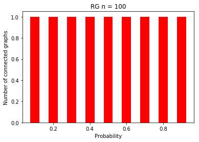

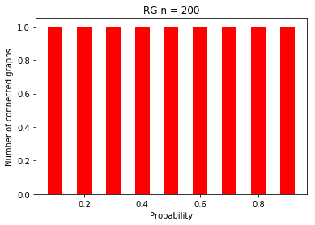

```python
#έλεγχος συνεκτικότητας RG Gilbert
#για την κατασκευή της RG χρησιμοποιήστε τη συνάρτηση gnp_random_graph του networkx.
#για τον έλεγχο της συνεκτικότητας, χρησιμοποίηστε την is_connected του networkx
#για τη γραφική αναπαράσταση των αποτελεσμάτων, μπορείτε να χρησιμοποίησετε την bar του matplotlib
#έλεγχος συνεκτικότητας για RG

# Επιστρεφω το ποσοστο των συνδεδεμενων γραφηματων
def RG_connect_per(p, n, fn):
    connected = 0
    for i in range(100): # 100 different topologies
        tmp_RG = fn(n, p)
        connected = connected + nx.is_connected(tmp_RG)
    return connected / 100


#plot example:
def plot_connect_RG(n, idx, fn):
    plt.figure(idx)
    y = [RG_connect_per(p, n, fn) for p in np.arange(0.1,1,0.1)]
    plt.bar(list(np.arange(0.1,1,0.1)), y, width=0.05, color='r')
    plt.title("RG n = %d" %n)
    plt.ylabel("Number of connected graphs")
    plt.xlabel("Probability")
    plt.show()

rg_fn = lambda n,p:nx.gnp_random_graph(n, p)
plot_connect_RG(100, 1, rg_fn)
plot_connect_RG(200, 2, rg_fn)
```

Σχολιάστε τα αποτελέσματα συνεκτικότητας για το RG Gilbert:

Λαμβάνουμε ποσοστό 100%, αφού στα τυχαία γραφήματα δημιουργούνται giant components με τα οποία είναι συνδεδεμένοι όλοι οι κόμβοι εάν το mean degree κόμβου είναι μεγαλύτερο της μονάδας. Από την άσκησή μας, βλέπουμε πως αυτό προκύπτει, δεδομένου ότι για κάθε τιμή της πιθανότητας p που δίνουμε, οι ακμές είναι πολύ περισσότερες από τις κορυφές.

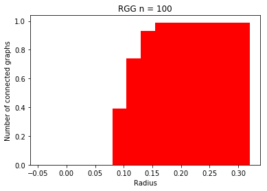

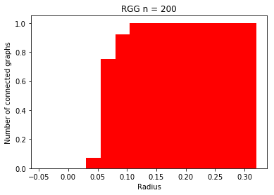

```python
import numpy as np

#για τον έλεγχο της συνεκτικότητας, χρησιμοποίηστε την is_connected του networkx
#για τη γραφική αναπαράσταση των αποτελεσμάτων, μπορείτε να χρησιμοποίησετε την bar του matplotlib
#έλεγχος συνεκτικότητας για RGG

# Επιστρεφω το ποσοστο των συνδεδεμενων γραφηματων
def RGG_connect_per(R, n, fn):
    connected = 0
    for i in range(100): # 100 different topologies
        tmp_RGG = fn(n, R)
        connected = connected + nx.is_connected(tmp_RGG)
    return connected / 100


#plot example:
def plot_connect_RGG(n, idx, fn):
    plt.figure(idx)
    y = [RGG_connect_per(R, n, fn) for R in np.arange(0.025,0.275,0.025)]
    plt.bar(list(np.arange(0.025,0.275,0.025)), y, width=0.14, color='r')
    plt.title("RGG n = %d" %n)
    plt.ylabel("Number of connected graphs")
    plt.xlabel("Radius")
    plt.show()

rgg_fn = lambda n,R:nx.random_geometric_graph(n, R, dim=2)
plot_connect_RGG(100, 1, rgg_fn)
plot_connect_RGG(200, 2, rgg_fn)
```

Σχολιάστε τα αποτελέσματα συνεκτικότητας για το RGG:

Γνωρίζουμε ότι η δημιουργία του γραφήματος RGG καθορίζεται από την τιμή που θέτουμε στην παράμετρο της ακτίνας r. Όσο μεγαλύτερη είναι η ακτίνα r τόσο περισσότερες συνδέσεις αναμένεται να έχει ο κάθε κόμβος, με αποτέλεσμα με την αύξηση του r να αναμένουμε το γράφημα που προκύπτει κάθε φορά να είναι όλο και πιο πολύ συνδεδεμένο. Το παραπάνω συμπέρασμα προκύπτει και από την άσκησή μας, αφού με την αύξηση του r βλέπουμε μόνο αύξηση του ποσοστού της συνεκτικότητας των γραφημάτων που προκύπτουν.

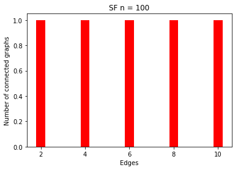

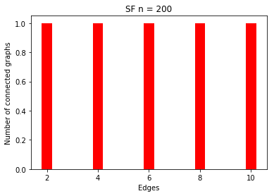

```python
#για τον έλεγχο της συνεκτικότητας, χρησιμοποίηστε την is_connected του networkx
#για τη γραφική αναπαράσταση των αποτελεσμάτων, μπορείτε να χρησιμοποίησετε την bar του matplotlib
#έλεγχος συνεκτικότητας για SF

# Επιστρεφω το ποσοστο των συνδεδεμενων γραφηματων
def SF_connect_per(d, n, fn):
    connected = 0
    for i in range(100): # 100 different topologies
        tmp_SF = fn(n, d)
        connected = connected + nx.is_connected(tmp_SF)
    return connected / 100


#plot example:
def plot_connect_SF(n, idx, fn):
    plt.figure(idx)
    y = [SF_connect_per(d, n, fn) for d in range(2,12,2)]
    plt.bar(list(range(2,12,2)), y, width=0.4, color='r')
    plt.title("SF n = %d" %n)
    plt.ylabel("Number of connected graphs")
    plt.xlabel("Edges")
    plt.show()

sf_fn = lambda n,d:nx.barabasi_albert_graph(n, d)
plot_connect_SF(100, 1, sf_fn)
plot_connect_SF(200, 2, sf_fn)
```

Σχολιάστε τα αποτελέσματα συνεκτικότητας για το SF:

Ανεξάρτητα με την τιμή των παραμέτρων, λαμβάνουμε κάθε φορά συνεκτικότητα στον γράφο, γεγόνος που οφείλεται στο ότι κάθε νέος κόμβος συνδέεται με ήδη υπάρχοντες κόμβους, απλώς με την ιδιότητα να τείνουν να συνδεόνται με τους αυτούς που έχουν πιο μεγάλο βαθμό. Έτσι, πάντοτε εξασφαλίζεται η συνεκτικότητα.

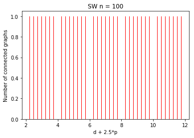

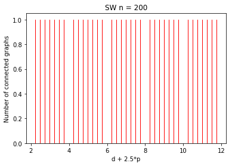

```python
# για την κατασκευή της SW, χρησιμοποιήστε την connected_watts_strogatz_graph()
#για τον έλεγχο της συνεκτικότητας, χρησιμοποίηστε την is_connected του networkx
#για τη γραφική αναπαράσταση των αποτελεσμάτων, μπορείτε να χρησιμοποίησετε την bar του matplotlib
#έλεγχος συνεκτικότητας για SW

# Επιστρεφω το ποσοστο των συνδεδεμενων γραφηματων
def SW_connect_per(d, p, n, fn):
    connected = 0
    for i in range(100): # 100 different topologies
        tmp_SW = fn(n, d, p)
        connected = connected + nx.is_connected(tmp_SW)
    return connected / 100


#plot example:
def plot_connect_SW(n, idx, fn):
    plt.figure(idx)
    y = [SW_connect_per(d, p, n, fn) for d in range(2,12,2) for p in np.arange(0.1,0.8,0.1)]
    plt.bar([d+2.5*p for d in range(2,12,2) for p in np.arange(0.1,0.8,0.1)], y, width=0.03, color='r')
    plt.title("SW n = %d" %n)
    plt.ylabel("Number of connected graphs")
    plt.xlabel("d + 2.5*p")
    plt.show()

sw_fn = lambda n,d,p:nx.connected_watts_strogatz_graph(n, d, p)
plot_connect_SW(100, 1, sw_fn)
plot_connect_SW(200, 2, sw_fn)
```

**Σχολιάστε τα αποτελέσματα συνεκτικότητας για το SW:**

Όμοια με το SF, λαμβάνουμε ποσοστό 100% που οφείλεται στην συνάρτηση που χρησιμοποιήσαμε που απαιτεί οι γράφοι να είναι συνδεδεμένοι εξ αρχής.

- Σε ποιες περιπτώσεις εμφανίζονται φαινόμενα κατωφλίου;

Παρατηρούμε φαινόμενα κατωφλιού στα RGER, RGG models.  
Στο RGER, οφείλονται στο πλήθος των κόμβων, που όταν αυξάνεται ανεβάζει το κατώθλι προς τα πάνω, ενισχύοντας την ανάγκη για πιο πολλές ακμές, προκειμένουν να υπάρξει γράφημα.  
Στο RGG, οφείλονται στην γεωμετρία και την παράμετρο της ακτίνας.

- Ποιες είναι οι κρίσιμες τιμές για κάθε τύπο δικτύου οι οποίες οδηγούν σε μετάβαση φάσης (phase transitions); Ποιες μεταβάσεις φάσης είναι απότομες (sharp) και ποιες ομαλές (smooth);

Στο RGER: για n = 100, M = 300(sharp), 400(smooth), για n = 200, Μ = 500(sharp), 600(sharp), 700(sharp), 800(smooth)  
Στο RGG: για n = 100, r = 0.11(sharp), 0.13(sharp), 0.17(smooth) για n = 200, r = 0.052(sharp), 0.07(smooth), 0.11 (smooth)

### Θ) Μελέτη μοντέλων τυχαίων γράφων

Συμπληρώστε τα κενά 1,2,3,4,5 του παρακάτω πίνακα (αναλυτική λύση) ώστε να υπάρχει αντιστοιχία μεταξύ των δύο μοντέλων τυχαίων γράφων (Gilbert, Erdos-Renyi). Τι παρατηρείτε;

[output not shown]

```python
#Απάντηση στο ερώτημα Θ:
print("1:495")
print("2:1000")
print("3:49995")
print("4:" + str(10**(-4)))
print("5:1000000")
```

```
1:495
2:1000
3:49995
4:0.0001
5:1000000
```

### Αιτιολόγηση

Προκειμένου να λύσουμε το παραπάνω ερώτημα, θα κάνουμε χρήση της υπόθεσης ότι $N^2 p \to \infty$. Σκοπός μας είναι η αναγωγή του ενός μοντέλο στο άλλο. Χρησιμοποιούμε τον νόμο των μεγάλων αριθμών και λαμβάνουμε για το G(N,p) ότι το αναμενόμενο πλήθος ακμών του θα είναι ίσο με ${N\choose 2}p$. Ακόμα, προκειμένου να αποκτήσουμε την ισοδυναμία των δύο μοντέλων, απαιτούμε το παραπάνω πλήθος στο ένα μοντέλο να ισούται με το Μ του άλλου και επιλύουμε την σχέση. Έτσι, λύνουμε την σχέση $Μ = {Ν \choose 2}p$ και παίρνουμε τα παραπάνω αποτελέσματα.

### Ι) Μελέτη της εξελικτικής μετατροπής δικτύου REG σε δίκτυο SW και RGER

Μεταβάλλοντας την παράμετρο $g_p$ της συνάρτησης που κατασκευάζει τοπολογίες SW, από $0$ έως $1$ με βήμα $0.1$, να βρείτε το μέσο μήκος μονοπατιού και το μέσο συντελεστή ομαδοποίησης. Πώς συμπεριφέρεται το παραγώμενο δίκτυο για $g_p = 0$, πώς για $g_p = 1$ και πώς για ενδιάμεσες τιμές $g_p \simeq 0.1 - 0.5$;

```python
n = 170
d = 4

def compute_path_lengths(G):
    return nx.all_pairs_shortest_path_length(G)


def getLengths(G_path_lengths):
    lengths = []
    for item in G_path_lengths:
        item_dict = item[1]
        for value in item_dict.values():
            lengths.append(value)

    return lengths


def calculate_clust_coef(G):
    return nx.clustering(G)


for p in list(np.linspace(0, 1, 11)):
    p = int(p*10) / 10
    if (p == 1 or p == 0):
        p = int(p)
    sw = nx.watts_strogatz_graph(n, d, p)
    sw_path_lengths = list(compute_path_lengths(sw))
    sw_lengths = getLengths(sw_path_lengths)
    sw_clust_coef = calculate_clust_coef(sw)
    print("Mean path length, p = " + str(p) + ": \t\t" +  str(np.mean(sw_lengths)))
    print("Mean clustering coefficient: \t\t" + str(np.mean(list(sw_clust_coef.values()))))
    print()
```

```
Mean path length, p = 0: 		21.5
Mean clustering coefficient: 		0.5

Mean path length, p = 0.1: 		5.88719723183391
Mean clustering coefficient: 		0.37725490196078426

Mean path length, p = 0.2: 		4.95522491349481
Mean clustering coefficient: 		0.2815126050420168

Mean path length, p = 0.3: 		4.443598615916955
Mean clustering coefficient: 		0.20652661064425773

Mean path length, p = 0.4: 		4.107612456747405
Mean clustering coefficient: 		0.10952380952380954

Mean path length, p = 0.5: 		4.074602076124568
Mean clustering coefficient: 		0.12572829131652663

Mean path length, p = 0.6: 		3.9254671280276816
Mean clustering coefficient: 		0.0384500466853408

Mean path length, p = 0.7: 		3.884636678200692
Mean clustering coefficient: 		0.027637721755368817

Mean path length, p = 0.8: 		3.9305190311418685
Mean clustering coefficient: 		0.03215686274509804

Mean path length, p = 0.9: 		3.903114186851211
Mean clustering coefficient: 		0.02372549019607843

Mean path length, p = 1: 		3.9121799307958476
Mean clustering coefficient: 		0.03215686274509804
```

### Σχολιασμός εξελικτικής μετατροπής:

Παρατηρούμε ότι για πιθανότητα ανασύνδεσης p ίση με το 0, προκύπτει το REG με τον ίδιο ΣΟ και mean path length που είχε υπολογιστεί παραπάνω. Τα αποτελέσματα των δυο αυτών μετρικών έχουν αιτιολογηθεί παραπάνω.  
Για πιθανότητες p με τιμές ενδιάμεσα του 0 και του 1, παρατηρούμε τοπολογίες τύπου small world, όπως και στο αρχικό SW γράφο που φτιάχτηκε θέτοντας την παράμετρο $p=0.3$.  
Τέλος, για τια πιθανότητα p ίση με 1 λαμβάνουμε τυχαίο γράφο, δεδομένου ότι έχουμε για όλες τις ακμές αναδιόρθωση ακμών με τυχαίο τρόπο.

### Κ) Εγω-κεντρικότητες (Ego-centralities)

Για τις συνθετικές τοπολογίες του πίνακα 1, να υπολογιστεί η ενδιαμεσική εγω-κεντρικότητα (ego-betweenness centrality) του κάθε κόμβου. Στη συνέχεια να καταταχθούν οι κόμβοι με βάση την ενδιαμεσική εγωκεντρικότητα και την ενδιαμεσική κεντρικότητα και να συγκριθούν/σχολιαστούν οι κατατάξεις ως προς την ομοιότητά τους για κάθε μία τοπολογία.

```python
#για την κατασκευή των εγωδικτύων, χρησιμοποιήστε την ego_graph του networkx
#για τον υπολογισμό της ενδιαμεσικής εγωκεντρικότητας θα χρειαστείτε τις adjacency_matrix (networkx), to.dense, ones (numpy)
#linalg.matrix_power, multiply, triu, nonzero του numpy
#κατασκευάστε dataframe από το pandas με γραμμές τους κόμβους και στήλες τις τιμές των υπό εξέταση κεντρικοτήτων
#κατασκευάστε στη συνέχεια pairplot από το seaborn για να εξετάσετε τις συσχετίσεις μεταξύ τους.
```

```python
d = 4
# Lattice -> p = 0
REG =  nx.watts_strogatz_graph(n, d, 0, seed=None)

M = 750
# για την κατασκευή του RGER χρησιμοποιήστε την gnm_random_graph από το networkx
RGER = nx.gnm_random_graph(n, M)

R = 0.25
L = 1
n = 170
# για την κατασκευή του RGG, χρησιμοποιήστε την random_geometric_graph από το networkx
RGG = nx.random_geometric_graph(n, R, dim=2)

d = 4
# για την κατασκευή του SF, χρησιμοποιήστε την barabasi_albert_graph από το networkx.
SF = nx.barabasi_albert_graph(n, d)

n = 170
d = 4
p = 0.3
# για την κατασκευή του SW, χρησιμοποιήστε την watts_strogatz_graph από το networkx.
SW = nx.watts_strogatz_graph(n, d, p)

def ego_central(topology, name):
    ego_centrality_list = []
    for node in REG.nodes():
        node_ego = nx.ego_graph(topology, node)
        # adjacency matrix
        A = (nx.adj_matrix(node_ego)).todense()
        # A^2 * (1-A)
        hadamard = np.multiply(np.matmul(A,A), (1-A))
        triu = np.triu(hadamard, 1)
        triu = triu[triu > 0]
        ego_betweenness = np.sum([1/i for i in triu])
        ego_centrality_list.append(ego_betweenness / 2)

    print("Ego-centralities for each node in " + name + ": \n" + str(ego_centrality_list) + "\n")
    return ego_centrality_list

ego_reg = ego_central(REG, "REG")
ego_rger = ego_central(RGER, "RGER")
ego_rgg = ego_central(RGG, "RGG")
ego_sf = ego_central(SF, "SF")
ego_sw = ego_central(SW, "SW")
```

```
Ego-centralities for each node in REG:
[1.0, 1.0, 1.0, 1.0, 1.0, 1.0, 1.0, 1.0, 1.0, 1.0, 1.0, 1.0, 1.0, 1.0, 1.0, 1.0, 1.0, 1.0, 1.0, 1.0, 1.0, 1.0, 1.0, 1.0, 1.0, 1.0, 1.0, 1.0, 1.0, 1.0, 1.0, 1.0, 1.0, 1.0, 1.0, 1.0, 1.0, 1.0, 1.0, 1.0, 1.0, 1.0, 1.0, 1.0, 1.0, 1.0, 1.0, 1.0, 1.0, 1.0, 1.0, 1.0, 1.0, 1.0, 1.0, 1.0, 1.0, 1.0, 1.0, 1.0,…

Ego-centralities for each node in RGER:
[10.5, 10.5, 27.75, 49.0, 1.0, 37.25, 12.0, 26.5, 5.0, 31.5, 24.25, 24.0, 25.5, 37.5, 26.5, 21.5, 17.5, 26.5, 17.0, 50.75, 10.5, 32.0, 0.5, 27.0, 9.25, 10.0, 35.75, 56.0, 13.5, 22.0, 7.0, 27.0, 18.0, 32.5, 25.75, 0.0, 13.5, 42.0, 12.25, 26.0, 33.0, 17.5, 21.5, 7.0, 13.5, 14.0, 27.5, 2.5, 0.5, 10.0, …

Ego-centralities for each node in RGG:
[9.120460095460095, 8.415476190476191, 16.55148469736318, 2.8210603938545114, 2.2289053266994436, 0.2986111111111111, 16.397825785325786, 6.935357208151325, 0.05555555555555555, 5.92761544011544, 7.629578060828061, 1.9748376623376622, 15.50727466977467, 17.80780163463987, 17.42938866688867, 11.97939…

Ego-centralities for each node in SF:
[280.04166666666663, 168.41666666666666, 49.0, 7.0, 382.8666666666667, 35.08333333333333, 178.375, 216.08333333333331, 67.08333333333333, 26.5, 35.75, 58.5, 48.08333333333333, 11.166666666666666, 19.25, 20.416666666666664, 14.0, 155.75, 47.75, 70.33333333333333, 64.33333333333333, 64.0, 30.75, 109.0…

Ego-centralities for each node in SW:
[2.5, 2.5, 3.0, 1.5, 0.5, 0.5, 0.5, 1.0, 3.75, 1.75, 6.5, 2.5, 4.5, 2.5, 1.75, 5.5, 1.75, 7.0, 2.5, 2.5, 2.5, 1.0, 1.75, 1.0, 2.5, 3.75, 3.0, 2.5, 0.25, 1.0, 1.0, 1.0, 3.0, 3.0, 1.75, 2.5, 1.0, 2.5, 2.5, 2.5, 2.5, 2.0, 0.25, 5.5, 3.75, 4.5, 2.5, 3.75, 1.0, 1.0, 3.75, 2.5, 3.0, 1.5, 1.0, 3.75, 1.75, …
```

```python
import pandas as pd
# DataFrame (n nodes) x 2(ego-centrality, betweenness) --- print first 5 records
df_reg = pd.DataFrame({'Ego Centrality': ego_reg, 'Betweenness Centrality': list(REG_betweenness_centrality.values())})
print(df_reg.head())

df_rger = pd.DataFrame({'Ego Centrality': ego_rger, 'Betweenness Centrality': list(RGER_betweenness_centrality.values())})
print(df_rger.head())

df_rgg = pd.DataFrame({'Ego Centrality': ego_rgg, 'Betweenness Centrality': list(RGG_betweenness_centrality.values())})
print(df_rgg.head())

df_sf = pd.DataFrame({'Ego Centrality': ego_sf, 'Betweenness Centrality': list(SF_betweenness_centrality.values())})
print(df_sf.head())

df_sw = pd.DataFrame({'Ego Centrality': ego_sw, 'Betweenness Centrality': list(SW_betweenness_centrality.values())})
print(df_reg.head())
```

```
   Ego Centrality  Betweenness Centrality
0             1.0                0.122781
1             1.0                0.122781
2             1.0                0.122781
3             1.0                0.122781
4             1.0                0.122781
   Ego Centrality  Betweenness Centrality
0           10.50                0.005221
1           10.50                0.011644
2           27.75                0.013857
3           49.00                0.015040
4            1.00                0.011553
   Ego Centrality  Betweenness Centrality
0        9.120460                0.013612
1        8.415476                0.016815
2       16.551485                0.000372
3        2.821060                0.004532
4        2.228905                0.044580
   Ego Centrality  Betweenness Centrality
0      280.041667                0.027992
1      168.416667                0.000205
2       49.000000                0.003699
3        7.000000                0.066202
4      382.866667                0.108510
   Ego Centrality  Betweenness Centrality
0             1.0                0.122781
1             1.0                0.122781
2             1.0                0.122781
3             1.0                0.122781
4             1.0                0.122781
```

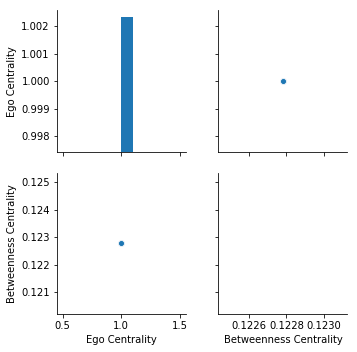

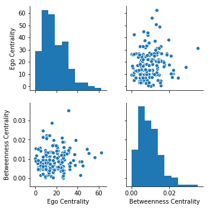

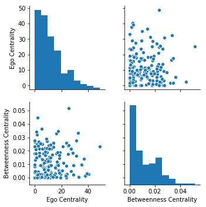

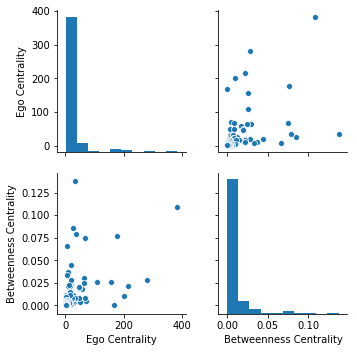

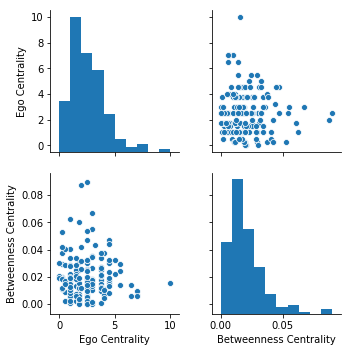

```python
sns.pairplot(df_reg)
sns.pairplot(df_rger)
sns.pairplot(df_rgg)
sns.pairplot(df_sf)
sns.pairplot(df_sw)
```

**Σύγκριση REG**  
Στο REG model, παρατηρούμε σταθερές τις τιμές της εγωκεντρικότητας και τις ενδιάμεσης κεντρικότητας. Βλέπουμε οι δύο αυτές τιμές να αποκλίνουν μεταξύ τους αρκετά. Ωστόσο, μπορούμε να πούμε ότι είναι παρόμοιες από ποιοτική άποψη.